# Project: Investigate a Dataset - TMDb movie data

### Research Question 1: How are the budgets and revenues for movies related?

First thing that might come to mind when you are asked this question about this data set might be "Does the movie with highest budget have the gighest revenue?", therefore, we need to sort the rows accodring to the budget to answer basic questions. First, Let's see the biggest revenue for a movie ever.

```python
#Let's see the movie with the biggest revenue ever
df[df["revenue"] == df.revenue.max()]
```

|  | id | popularity | budget | revenue | original_title | cast | director | tagline | keywords | overview | runtime | genres | production_companies | release_date | vote_count | vote_average | budget_adj | revenue_adj |
| --- | --- | --- | --- | --- | --- | --- | --- | --- | --- | --- | --- | --- | --- | --- | --- | --- | --- | --- |
| 1386 | 19995 | 9.432768 | 237000000 | 2781505847 | Avatar | Sam Worthington\|Zoe Saldana\|Sigourney Weaver\|S... | James Cameron | Enter the World of Pandora. | culture clash\|future\|space war\|space colony\|so... | In the 22nd century, a paraplegic Marine is di... | 162 | Action\|Adventure\|Fantasy\|Science Fiction | Ingenious Film Partners\|Twentieth Century Fox ... | 2009-12-10 | 8458 | 7.1 | 2.408869e+08 | 2.827124e+09 |

Woah! Thats a huge revenue! And This budget does not seem that big compared to the revenue? Then let's check out the movie with the biggest budget.

```python
df[df["budget"] == df.budget.max()]
```

|  | id | popularity | budget | revenue | original_title | cast | director | tagline | keywords | overview | runtime | genres | production_companies | release_date | vote_count | vote_average | budget_adj | revenue_adj |
| --- | --- | --- | --- | --- | --- | --- | --- | --- | --- | --- | --- | --- | --- | --- | --- | --- | --- | --- |
| 2244 | 46528 | 0.25054 | 425000000 | 11087569 | The Warrior's Way | Kate Bosworth\|Jang Dong-gun\|Geoffrey Rush\|Dann... | Sngmoo Lee | Assassin. Hero. Legend. | assassin\|small town\|revenge\|deception\|super speed | An Asian assassin (Dong-gun Jang) is forced to... | 100 | Adventure\|Fantasy\|Action\|Western\|Thriller | Boram Entertainment Inc. | 2010-12-02 | 74 | 6.4 | 425000000.0 | 11087569.0 |

Aw... What a shame, a movie with this big of a budget has this little revenue? It must have been very hard on the producers! Anyway, comapred to the one with the biggest revenue, this movie's budget is almost twice the amount!

But those are simple queries about movies' budget and revenue, let's dive deeper into statistics related to them.

```python
# Making a copy of the dataframe with rows sorted according to budget in decending order
df_q1 = df.sort_values(by='budget', ascending=False)
df_q1.head()
```

|  | id | popularity | budget | revenue | original_title | cast | director | tagline | keywords | overview | runtime | genres | production_companies | release_date | vote_count | vote_average | budget_adj | revenue_adj |
| --- | --- | --- | --- | --- | --- | --- | --- | --- | --- | --- | --- | --- | --- | --- | --- | --- | --- | --- |
| 2244 | 46528 | 0.250540 | 425000000 | 11087569 | The Warrior's Way | Kate Bosworth\|Jang Dong-gun\|Geoffrey Rush\|Dann... | Sngmoo Lee | Assassin. Hero. Legend. | assassin\|small town\|revenge\|deception\|super speed | An Asian assassin (Dong-gun Jang) is forced to... | 100 | Adventure\|Fantasy\|Action\|Western\|Thriller | Boram Entertainment Inc. | 2010-12-02 | 74 | 6.4 | 4.250000e+08 | 1.108757e+07 |
| 3375 | 1865 | 4.955130 | 380000000 | 1021683000 | Pirates of the Caribbean: On Stranger Tides | Johnny Depp\|PenÃ©lope Cruz\|Geoffrey Rush\|Ian M... | Rob Marshall | Live Forever Or Die Trying. | sea\|captain\|mutiny\|sword\|prime minister | Captain Jack Sparrow crosses paths with a woma... | 136 | Adventure\|Action\|Fantasy | Walt Disney Pictures\|Jerry Bruckheimer Films\|M... | 2011-05-11 | 3180 | 6.3 | 3.683713e+08 | 9.904175e+08 |
| 7387 | 285 | 4.965391 | 300000000 | 961000000 | Pirates of the Caribbean: At World's End | Johnny Depp\|Orlando Bloom\|Keira Knightley\|Geof... | Gore Verbinski | At the end of the world, the adventure begins. | ocean\|drug abuse\|exotic island\|east india trad... | Captain Barbossa, long believed to be dead, ha... | 169 | Adventure\|Fantasy\|Action | Walt Disney Pictures\|Jerry Bruckheimer Films\|S... | 2007-05-19 | 2626 | 6.8 | 3.155006e+08 | 1.010654e+09 |
| 14 | 99861 | 5.944927 | 280000000 | 1405035767 | Avengers: Age of Ultron | Robert Downey Jr.\|Chris Hemsworth\|Mark Ruffalo... | Joss Whedon | A New Age Has Come. | marvel comic\|comic\|sequel\|superhero\|vision | When Tony Stark tries to jumpstart a dormant p... | 141 | Action\|Adventure\|Science Fiction | Marvel Studios\|Prime Focus\|Revolution Sun Studios | 2015-04-22 | 4304 | 7.4 | 2.575999e+08 | 1.292632e+09 |
| 6570 | 1452 | 1.957331 | 270000000 | 391081192 | Superman Returns | Brandon Routh\|Kevin Spacey\|Kate Bosworth\|James... | Bryan Singer | NA | saving the world\|dc comics\|invulnerability\|seq... | Set 5 years after the end of Superman II, the ... | 154 | Adventure\|Fantasy\|Action\|Science Fiction | DC Comics\|Legendary Pictures\|Warner Bros.\|Bad ... | 2006-06-28 | 834 | 5.3 | 2.920507e+08 | 4.230205e+08 |

To make it easy for us, we will divide movies to groups based on budget.

```python
# Defining the budget ranges
budget_bins = [0, 1000, 10000, 50000, 100000, 200000, 500000, 700000,
               1000000, 2000000, 5000000, 7000000, 10000000, 20000000, 30000000,
               40000000, 50000000, 70000000, 80000000, 100000000, 200000000, 500000000]

# Defining the corresponding budget range labels
budget_labels = [1000, 10000, 50000, 100000, 200000, 500000, 700000,
               1000000, 2000000, 5000000, 7000000, 10000000, 20000000, 30000000,
               40000000, 50000000, 70000000, 80000000, 100000000, 200000000, 500000000]

# Creating the new column 'budget_range_under'
df_q1['budget_range_under'] = pd.cut(df_q1['budget'], bins=budget_bins, labels=budget_labels, right=False)
df_q1.head()
```

|  | id | popularity | budget | revenue | original_title | cast | director | tagline | keywords | overview | runtime | genres | production_companies | release_date | vote_count | vote_average | budget_adj | revenue_adj | budget_range_under |
| --- | --- | --- | --- | --- | --- | --- | --- | --- | --- | --- | --- | --- | --- | --- | --- | --- | --- | --- | --- |
| 2244 | 46528 | 0.250540 | 425000000 | 11087569 | The Warrior's Way | Kate Bosworth\|Jang Dong-gun\|Geoffrey Rush\|Dann... | Sngmoo Lee | Assassin. Hero. Legend. | assassin\|small town\|revenge\|deception\|super speed | An Asian assassin (Dong-gun Jang) is forced to... | 100 | Adventure\|Fantasy\|Action\|Western\|Thriller | Boram Entertainment Inc. | 2010-12-02 | 74 | 6.4 | 4.250000e+08 | 1.108757e+07 | 500000000 |
| 3375 | 1865 | 4.955130 | 380000000 | 1021683000 | Pirates of the Caribbean: On Stranger Tides | Johnny Depp\|PenÃ©lope Cruz\|Geoffrey Rush\|Ian M... | Rob Marshall | Live Forever Or Die Trying. | sea\|captain\|mutiny\|sword\|prime minister | Captain Jack Sparrow crosses paths with a woma... | 136 | Adventure\|Action\|Fantasy | Walt Disney Pictures\|Jerry Bruckheimer Films\|M... | 2011-05-11 | 3180 | 6.3 | 3.683713e+08 | 9.904175e+08 | 500000000 |
| 7387 | 285 | 4.965391 | 300000000 | 961000000 | Pirates of the Caribbean: At World's End | Johnny Depp\|Orlando Bloom\|Keira Knightley\|Geof... | Gore Verbinski | At the end of the world, the adventure begins. | ocean\|drug abuse\|exotic island\|east india trad... | Captain Barbossa, long believed to be dead, ha... | 169 | Adventure\|Fantasy\|Action | Walt Disney Pictures\|Jerry Bruckheimer Films\|S... | 2007-05-19 | 2626 | 6.8 | 3.155006e+08 | 1.010654e+09 | 500000000 |
| 14 | 99861 | 5.944927 | 280000000 | 1405035767 | Avengers: Age of Ultron | Robert Downey Jr.\|Chris Hemsworth\|Mark Ruffalo... | Joss Whedon | A New Age Has Come. | marvel comic\|comic\|sequel\|superhero\|vision | When Tony Stark tries to jumpstart a dormant p... | 141 | Action\|Adventure\|Science Fiction | Marvel Studios\|Prime Focus\|Revolution Sun Studios | 2015-04-22 | 4304 | 7.4 | 2.575999e+08 | 1.292632e+09 | 500000000 |
| 6570 | 1452 | 1.957331 | 270000000 | 391081192 | Superman Returns | Brandon Routh\|Kevin Spacey\|Kate Bosworth\|James... | Bryan Singer | NA | saving the world\|dc comics\|invulnerability\|seq... | Set 5 years after the end of Superman II, the ... | 154 | Adventure\|Fantasy\|Action\|Science Fiction | DC Comics\|Legendary Pictures\|Warner Bros.\|Bad ... | 2006-06-28 | 834 | 5.3 | 2.920507e+08 | 4.230205e+08 | 500000000 |

```python
# Converting the 'budget_range_under' column to a categorical data type
df_q1['budget_range_under'] = pd.Categorical(df_q1['budget_range_under'], categories=budget_labels, ordered=True)
df_q1['budget_range_under'].dtype
```

```
CategoricalDtype(categories=[     1000,     10000,     50000,    100000,    200000,
                     500000,    700000,   1000000,   2000000,   5000000,
                    7000000,  10000000,  20000000,  30000000,  40000000,
                   50000000,  70000000,  80000000, 100000000, 200000000,
                  500000000],
, ordered=True)
```

```python
# Let's now divide the movies to groups based on budget range
grouped_df = df_q1.groupby('budget_range_under').agg(
    total_revenue=('revenue', 'sum'),
    average_revenue=('revenue', 'mean')
).reset_index()
grouped_df.head(30)
```

|  | budget_range_under | total_revenue | average_revenue |
| --- | --- | --- | --- |
| 0 | 1000 | 17819313795 | 3.096319e+06 |
| 1 | 10000 | 900707 | 1.000786e+05 |
| 2 | 50000 | 462941406 | 1.780544e+07 |
| 3 | 100000 | 63326288 | 2.435626e+06 |
| 4 | 200000 | 155124649 | 4.192558e+06 |
| 5 | 500000 | 361349047 | 4.883095e+06 |
| 6 | 700000 | 244714365 | 3.764836e+06 |
| 7 | 1000000 | 339062338 | 4.986211e+06 |
| 8 | 2000000 | 1880523877 | 9.173287e+06 |
| 9 | 5000000 | 6601401306 | 1.307208e+07 |
| 10 | 7000000 | 7134482043 | 2.117057e+07 |
| 11 | 10000000 | 7144025642 | 2.178057e+07 |
| 12 | 20000000 | 38053955462 | 3.867272e+07 |
| 13 | 30000000 | 34854808843 | 5.194457e+07 |
| 14 | 40000000 | 32980366161 | 7.461621e+07 |
| 15 | 50000000 | 28799432254 | 1.024891e+08 |
| 16 | 70000000 | 48821548675 | 1.199547e+08 |
| 17 | 80000000 | 25662195714 | 1.794559e+08 |
| 18 | 100000000 | 36535822746 | 2.099760e+08 |
| 19 | 200000000 | 106688827514 | 3.810315e+08 |
| 20 | 500000000 | 38115103043 | 7.940646e+08 |

That should make it easier to handle. Ugh, numbers are cool and all but I can't seem to comprehend the relation by just looking at them. I think a couple graphs can simplify things, no? Let's see...

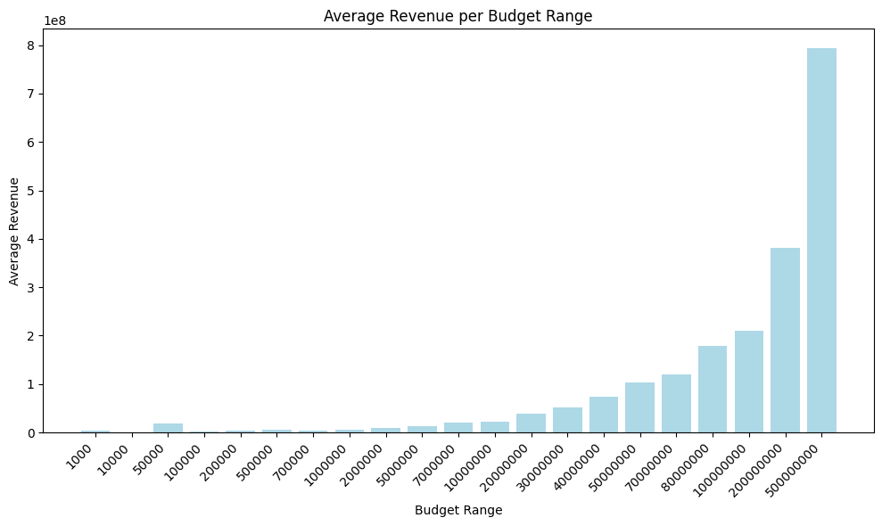

```python
import matplotlib.pyplot as plt

# Plotting average profit against budget range
plt.figure(figsize=(10, 6))
plt.bar(grouped_df['budget_range_under'].astype(str), grouped_df['average_revenue'], color='lightblue')

# Adding labels and title
plt.xlabel('Budget Range')
plt.ylabel('Average Revenue')
plt.title('Average Revenue per Budget Range')
plt.xticks(rotation=45, ha='right')
plt.tight_layout()

# Showing the plot
plt.show()
```

This plot alone should be enough to understan the relation between the budget and revenue, but i feel a pie chart could be helpful too...

[figure not shown]

```python
# Plotting average profit as a pie chart
plt.figure(figsize=(8, 8))
plt.pie(grouped_df['average_revenue'], labels=grouped_df['budget_range_under'].astype(str),
        autopct='%1.1f%%', startangle=140, colors=plt.cm.Paired.colors)

# Adding title
plt.title('Average Profit per Budget Range')

# Showing the plot
plt.show()
```

What a surprise, or is it? We can clearly see that on average, the higher the budget used on a movie, the higher the revenue it recieves as shown in the plots above. But is it ALWAYS the case? Do ALL movies with big budget recieve a hugh revenue in return? To see if that's really the case, we need to see how often a movie recieves negative profit.

```python
# Adding a column for the profit
df_q1['profit'] = df_q1['revenue'] - df_q1['budget']

# Anothr one for negative profit
df_q1['negative_profit'] = (df_q1['profit'] < 0)

# Grouping rows based on budget range, but this time, we are concerned with profit
grouped_df_negative = df_q1.groupby('budget_range_under').agg(
    negative_profit_sum=('negative_profit', 'sum')  # Sum of True values (negative profits count)
).reset_index()

grouped_df_negative.head(30)
```

|  | budget_range_under | negative_profit_sum |
| --- | --- | --- |
| 0 | 1000 | 40 |
| 1 | 10000 | 6 |
| 2 | 50000 | 16 |
| 3 | 100000 | 20 |
| 4 | 200000 | 26 |
| 5 | 500000 | 50 |
| 6 | 700000 | 45 |
| 7 | 1000000 | 46 |
| 8 | 2000000 | 131 |
| 9 | 5000000 | 295 |
| 10 | 7000000 | 195 |
| 11 | 10000000 | 195 |
| 12 | 20000000 | 475 |
| 13 | 30000000 | 317 |
| 14 | 40000000 | 174 |
| 15 | 50000000 | 95 |
| 16 | 70000000 | 137 |
| 17 | 80000000 | 43 |
| 18 | 100000000 | 45 |
| 19 | 200000000 | 34 |
| 20 | 500000000 | 2 |

We can see that most movie recieved good profit, but still, some seem to have lost profit. Let's plot them for better understanding.

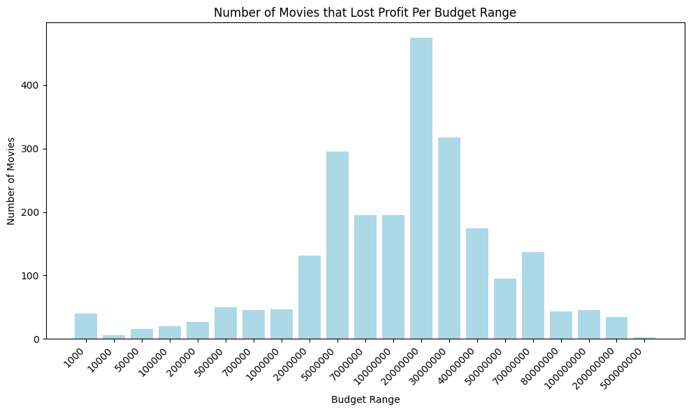

```python
# Plotting average profit against budget range
plt.figure(figsize=(10, 6))
plt.bar(grouped_df_negative['budget_range_under'].astype(str), grouped_df_negative['negative_profit_sum'], color='lightblue')

# Adding labels and title
plt.xlabel('Budget Range')
plt.ylabel('Number of Movies')
plt.title('Number of Movies that Lost Profit Per Budget Range')
plt.xticks(rotation=45, ha='right')  # Rotate x-axis labels for better readability
plt.tight_layout()

# Showing the plot
plt.show()
```

We can see from the figure that the number of movies with negative profit seems to be higher for movies within ranges above 1,000,000 and below 70,000,000, that is, around the mid point. It seems like that if the budget was too large, the chance of faluire will be smaller. Same goes for smaller budget, that is, if your budget is too low, even if your didn't make a huge hit, a little revenue is enough to make up for the loses used as budget.

Now that we have seen how budget can affect revenue in different budget ranges, it pique my curiosity: What are the top 10 movies in terms of percent profit? Let's find this out:

```python
# Some movies' budget is still not very accurate, and may have been entered wrong (usually under 1000),
# so we will not include these movies.
df_q1 = df_q1[df_q1['budget'] > 1000]

# Adding a row called percent_profit
df_q1['percent_profit'] = (df_q1['profit'] / df_q1['budget']) * 100

# Sorting according to percent profit
df_q1 = df_q1.sort_values(by='percent_profit', ascending=False)
df_q1.head(10)
```

|  | id | popularity | budget | revenue | original_title | cast | director | tagline | keywords | overview | ... | production_companies | release_date | vote_count | vote_average | budget_adj | revenue_adj | budget_range_under | profit | negative_profit | percent_profit |
| --- | --- | --- | --- | --- | --- | --- | --- | --- | --- | --- | --- | --- | --- | --- | --- | --- | --- | --- | --- | --- | --- |
| 7447 | 23827 | 1.120442 | 15000 | 193355800 | Paranormal Activity | Katie Featherston\|Micah Sloat\|Mark Fredrichs\|A... | Oren Peli | What Happens When You Sleep? | haunting\|psychic\|entity\|demonic possession\|fou... | After a young, middle class couple moves into ... | ... | Blumhouse Productions\|Solana Films | 2007-09-14 | 714 | 6.1 | 1.577503e+04 | 2.033462e+08 | 50000 | 193340800 | False | 1.288939e+06 |
| 2449 | 2667 | 0.934621 | 25000 | 248000000 | The Blair Witch Project | Heather Donahue\|Michael C. Williams\|Joshua Leo... | Daniel Myrick\|Eduardo SÃ¡nchez | The scariest movie of all time is a true story. | witch\|voodoo\|legend\|sorcery\|maryland | In October of 1994 three student filmmakers di... | ... | Artisan Entertainment\|Haxan Films | 1999-07-14 | 522 | 6.3 | 3.272632e+04 | 3.246451e+08 | 50000 | 247975000 | False | 9.919000e+05 |
| 1354 | 985 | 0.331417 | 10000 | 7000000 | Eraserhead | Jack Nance\|Charlotte Stewart\|Allen Joseph\|Jean... | David Lynch | Where your nightmares end... | baby\|mutant\|claustrophobia\|nightmare\|parents-i... | Henry Spencer tries to survive his industrial ... | ... | American Film Institute (AFI)\|Libra Films | 1977-03-19 | 194 | 7.1 | 3.597781e+04 | 2.518447e+07 | 50000 | 6990000 | False | 6.990000e+04 |
| 7277 | 692 | 0.412913 | 12000 | 6000000 | Pink Flamingos | Divine\|David Lochary\|Mary Vivian Pearce\|Mink S... | John Waters | An exercise in poor taste. | gay\|trailer park\|pop culture\|drug dealer\|heroin | Notorious Baltimore criminal and underground f... | ... | Dreamland Productions | 1972-03-12 | 51 | 6.3 | 6.257473e+04 | 3.128737e+07 | 50000 | 5988000 | False | 4.990000e+04 |
| 7178 | 9372 | 0.263897 | 65000 | 28575078 | Super Size Me | Morgan Spurlock\|Daryl Isaacs\|Lisa Ganjhu\|Steph... | Morgan Spurlock | The first ever reality-based movie ... everyth... | experiment\|health\|junk food\|food industry\|fast... | Morgan Spurlock subjects himself to a diet bas... | ... | Kathbur Pictures | 2004-01-17 | 295 | 6.5 | 7.503895e+04 | 3.298837e+07 | 100000 | 28510078 | False | 4.386166e+04 |
| 242 | 299245 | 0.532205 | 100000 | 42664410 | The Gallows | Cassidy Gifford\|Ryan Shoos\|Pfeifer Brown\|Reese... | Travis Cluff\|Chris Lofing | Every School Has Its Spirit | gallows\|high school\|tragedy\|hanging\|found footage | 20 years after a horrific accident during a sm... | ... | New Line Cinema\|Blumhouse Productions\|Manageme... | 2015-07-10 | 247 | 5.0 | 9.199996e+04 | 3.925124e+07 | 200000 | 42564410 | False | 4.256441e+04 |
| 7057 | 83 | 0.762134 | 130000 | 54667954 | Open Water | Blanchard Ryan\|Daniel Travis\|Saul Stein\|Michae... | Chris Kentis | Scream all you want. | diving\|cataclysm\|nightmare\|panic\|red sea | Two divers are left out at sea without a boat.... | ... | Plunge Pictures LLC | 2004-08-06 | 171 | 5.3 | 1.500779e+05 | 6.311117e+07 | 200000 | 54537954 | False | 4.195227e+04 |
| 9762 | 30497 | 0.906087 | 85000 | 30859000 | The Texas Chain Saw Massacre | Allen Danziger\|Paul A. Partain\|William Vail\|Te... | Tobe Hooper | Who will survive and what will be left of them? | texas\|chain saw\|gore\|midnight movie\|surprise e... | Five friends visiting their grandfather's hous... | ... | Vortex | 1974-10-01 | 249 | 6.8 | 3.758941e+05 | 1.364673e+08 | 100000 | 30774000 | False | 3.620471e+04 |
| 7827 | 9659 | 2.012021 | 400000 | 100000000 | Mad Max | Mel Gibson\|Joanne Samuel\|Hugh Keays-Byrne\|Stev... | George Miller | The Maximum Force Of The Future | chain\|baby\|bridge\|post-apocalyptic\|dystopia | In a dystopic future Australia, a vicious bike... | ... | Kennedy Miller Productions\|Mad Max Films\|Cross... | 1979-04-12 | 667 | 6.5 | 1.201822e+06 | 3.004554e+08 | 500000 | 99600000 | False | 2.490000e+04 |
| 10759 | 948 | 1.198849 | 300000 | 70000000 | Halloween | Donald Pleasence\|Jamie Lee Curtis\|P.J. Soles\|N... | John Carpenter | The Night HE Came Home! | female nudity\|nudity\|mask\|babysitter\|halloween | A psychotic murderer, institutionalized since ... | ... | Compass International Pictures\|Falcon Internat... | 1978-10-25 | 522 | 7.3 | 1.002810e+06 | 2.339890e+08 | 500000 | 69700000 | False | 2.323333e+04 |

10 rows × 22 columns

### Research Question 2: Which Genres Need The Highest Budget or Have the Highest Revenue Rates?

After having discussed movies and thier budgets, revenues and profit, I became curiose about geners, and how they can affect budget and profit. A good question, isn't it? Surely different genres need different amount of budget, right? And it's not wrong to assume different genres have different popularity, and therefore revenues, is it? If this was true, the following analysis would confirm.

Before anything, why not check out the genres of the movie with the biggest budget? Let's see...

```python
df[df['budget'] == df['budget'].max()]['genres']
```

```
2244    Adventure|Fantasy|Action|Western|Thriller
Name: genres, dtype: object
```

Intresting, but also to be expected. In any case, let's now check the genres of the movie with the highest revenue:

```python
df[df['revenue'] == df['revenue'].max()]['genres']
```

```
1386    Action|Adventure|Fantasy|Science Fiction
Name: genres, dtype: object
```

Hmm... We can see that 'Action' and 'Adventure' appeared in both, is there a connection? Let's analyze further:

```python
# Let's start by making a copy of the cleaned dataframe of the movies dataset
df_q2 = df.copy()

# This dataframe contains a column called 'genres' which has multiple values eperated by '|', we need
# to split each row based genre
df_q2['genres'] = df_q2['genres'].str.split('|')
df_q2 = df_q2.explode('genres', ignore_index=True)

# Renaming the column to 'genre', as each row now has one 'genre'
df_q2 = df_q2.rename(columns = {'genres' : 'genre'})
df_q2.head(10)
```

|  | id | popularity | budget | revenue | original_title | cast | director | tagline | keywords | overview | runtime | genre | production_companies | release_date | vote_count | vote_average | budget_adj | revenue_adj |
| --- | --- | --- | --- | --- | --- | --- | --- | --- | --- | --- | --- | --- | --- | --- | --- | --- | --- | --- |
| 0 | 135397 | 32.985763 | 150000000 | 1513528810 | Jurassic World | Chris Pratt\|Bryce Dallas Howard\|Irrfan Khan\|Vi... | Colin Trevorrow | The park is open. | monster\|dna\|tyrannosaurus rex\|velociraptor\|island | Twenty-two years after the events of Jurassic ... | 124 | Action | Universal Studios\|Amblin Entertainment\|Legenda... | 2015-06-09 | 5562 | 6.5 | 1.379999e+08 | 1.392446e+09 |
| 1 | 135397 | 32.985763 | 150000000 | 1513528810 | Jurassic World | Chris Pratt\|Bryce Dallas Howard\|Irrfan Khan\|Vi... | Colin Trevorrow | The park is open. | monster\|dna\|tyrannosaurus rex\|velociraptor\|island | Twenty-two years after the events of Jurassic ... | 124 | Adventure | Universal Studios\|Amblin Entertainment\|Legenda... | 2015-06-09 | 5562 | 6.5 | 1.379999e+08 | 1.392446e+09 |
| 2 | 135397 | 32.985763 | 150000000 | 1513528810 | Jurassic World | Chris Pratt\|Bryce Dallas Howard\|Irrfan Khan\|Vi... | Colin Trevorrow | The park is open. | monster\|dna\|tyrannosaurus rex\|velociraptor\|island | Twenty-two years after the events of Jurassic ... | 124 | Science Fiction | Universal Studios\|Amblin Entertainment\|Legenda... | 2015-06-09 | 5562 | 6.5 | 1.379999e+08 | 1.392446e+09 |
| 3 | 135397 | 32.985763 | 150000000 | 1513528810 | Jurassic World | Chris Pratt\|Bryce Dallas Howard\|Irrfan Khan\|Vi... | Colin Trevorrow | The park is open. | monster\|dna\|tyrannosaurus rex\|velociraptor\|island | Twenty-two years after the events of Jurassic ... | 124 | Thriller | Universal Studios\|Amblin Entertainment\|Legenda... | 2015-06-09 | 5562 | 6.5 | 1.379999e+08 | 1.392446e+09 |
| 4 | 76341 | 28.419936 | 150000000 | 378436354 | Mad Max: Fury Road | Tom Hardy\|Charlize Theron\|Hugh Keays-Byrne\|Nic... | George Miller | What a Lovely Day. | future\|chase\|post-apocalyptic\|dystopia\|australia | An apocalyptic story set in the furthest reach... | 120 | Action | Village Roadshow Pictures\|Kennedy Miller Produ... | 2015-05-13 | 6185 | 7.1 | 1.379999e+08 | 3.481613e+08 |
| 5 | 76341 | 28.419936 | 150000000 | 378436354 | Mad Max: Fury Road | Tom Hardy\|Charlize Theron\|Hugh Keays-Byrne\|Nic... | George Miller | What a Lovely Day. | future\|chase\|post-apocalyptic\|dystopia\|australia | An apocalyptic story set in the furthest reach... | 120 | Adventure | Village Roadshow Pictures\|Kennedy Miller Produ... | 2015-05-13 | 6185 | 7.1 | 1.379999e+08 | 3.481613e+08 |
| 6 | 76341 | 28.419936 | 150000000 | 378436354 | Mad Max: Fury Road | Tom Hardy\|Charlize Theron\|Hugh Keays-Byrne\|Nic... | George Miller | What a Lovely Day. | future\|chase\|post-apocalyptic\|dystopia\|australia | An apocalyptic story set in the furthest reach... | 120 | Science Fiction | Village Roadshow Pictures\|Kennedy Miller Produ... | 2015-05-13 | 6185 | 7.1 | 1.379999e+08 | 3.481613e+08 |
| 7 | 76341 | 28.419936 | 150000000 | 378436354 | Mad Max: Fury Road | Tom Hardy\|Charlize Theron\|Hugh Keays-Byrne\|Nic... | George Miller | What a Lovely Day. | future\|chase\|post-apocalyptic\|dystopia\|australia | An apocalyptic story set in the furthest reach... | 120 | Thriller | Village Roadshow Pictures\|Kennedy Miller Produ... | 2015-05-13 | 6185 | 7.1 | 1.379999e+08 | 3.481613e+08 |
| 8 | 262500 | 13.112507 | 110000000 | 295238201 | Insurgent | Shailene Woodley\|Theo James\|Kate Winslet\|Ansel... | Robert Schwentke | One Choice Can Destroy You | based on novel\|revolution\|dystopia\|sequel\|dyst... | Beatrice Prior must confront her inner demons ... | 119 | Adventure | Summit Entertainment\|Mandeville Films\|Red Wago... | 2015-03-18 | 2480 | 6.3 | 1.012000e+08 | 2.716190e+08 |
| 9 | 262500 | 13.112507 | 110000000 | 295238201 | Insurgent | Shailene Woodley\|Theo James\|Kate Winslet\|Ansel... | Robert Schwentke | One Choice Can Destroy You | based on novel\|revolution\|dystopia\|sequel\|dyst... | Beatrice Prior must confront her inner demons ... | 119 | Science Fiction | Summit Entertainment\|Mandeville Films\|Red Wago... | 2015-03-18 | 2480 | 6.3 | 1.012000e+08 | 2.716190e+08 |

```python
# Converting the 'genre' column to a categorical data type
df_q2['genre'] = pd.Categorical(df_q2['genre'], ordered=True)
df_q2['genre'].dtype
```

```
CategoricalDtype(categories=['Action', 'Adventure', 'Animation', 'Comedy', 'Crime',
                  'Documentary', 'Drama', 'Family', 'Fantasy', 'Foreign',
                  'History', 'Horror', 'Music', 'Mystery', 'NA', 'Romance',
                  'Science Fiction', 'TV Movie', 'Thriller', 'War', 'Western'],
, ordered=True)
```

```python
# Groups the dataframe by `group_col` and computes the average for columns in `value_cols`.
# Returns the resulting dataframe.
def group_and_average(df, group_col, value_cols):
    grouped_df = df.groupby(group_col)[value_cols].mean().reset_index()
    grouped_df.rename(columns={col: f'avg_{col}' for col in value_cols}, inplace=True)
    return grouped_df

# Plots a pie chart given a dataframe, value column, label column, and chart title.
def plot_pie_chart(df, value_col, label_col, title):
    plt.figure(figsize=(8,8))
    plt.pie(df[value_col], labels=df[label_col], autopct='%1.1f%%', startangle=140)
    plt.title(title)
    plt.axis('equal')
    plt.show()
```

```python
grouped_df_q2 = df_q2.groupby('genre')[['popularity', 'budget', 'revenue']].mean().reset_index()
grouped_df_q2.rename(columns={
    'popularity': 'avg_popularity',
    'budget': 'avg_budget',
    'revenue': 'avg_revenue'
}, inplace=True)
grouped_df_q2
```

|  | genre | avg_popularity | avg_budget | avg_revenue |
| --- | --- | --- | --- | --- |
| 0 | Action | 0.926274 | 2.772782e+07 | 7.279473e+07 |
| 1 | Adventure | 1.154259 | 3.754369e+07 | 1.131379e+08 |
| 2 | Animation | 0.852182 | 2.315978e+07 | 7.525606e+07 |
| 3 | Comedy | 0.592607 | 1.329792e+07 | 3.752624e+07 |
| 4 | Crime | 0.744930 | 1.766380e+07 | 4.236866e+07 |
| 5 | Documentary | 0.181432 | 5.771491e+05 | 2.041107e+06 |
| 6 | Drama | 0.591495 | 1.188072e+07 | 2.923226e+07 |
| 7 | Family | 0.786668 | 2.335934e+07 | 7.243318e+07 |
| 8 | Fantasy | 0.992840 | 3.261259e+07 | 9.631366e+07 |
| 9 | Foreign | 0.191496 | 1.451435e+06 | 1.520460e+06 |
| 10 | History | 0.575936 | 1.859492e+07 | 3.201179e+07 |
| 11 | Horror | 0.465357 | 6.226529e+06 | 1.682281e+07 |
| 12 | Music | 0.487321 | 9.438628e+06 | 2.857177e+07 |
| 13 | Mystery | 0.690012 | 1.611927e+07 | 4.021757e+07 |
| 14 | NA | 0.167966 | 2.173913e+02 | 0.000000e+00 |
| 15 | Romance | 0.592082 | 1.253127e+07 | 3.569197e+07 |
| 16 | Science Fiction | 1.001548 | 2.497268e+07 | 7.014056e+07 |
| 17 | TV Movie | 0.270896 | 2.676647e+05 | 2.514970e+05 |
| 18 | Thriller | 0.741563 | 1.720769e+07 | 4.172842e+07 |
| 19 | War | 0.727683 | 2.089189e+07 | 4.760518e+07 |
| 20 | Western | 0.590615 | 1.897411e+07 | 2.856871e+07 |

Let's sort them by budget to see how expensive each genre can be. The top five genres in terms of budget are

```python
grouped_df_q2.sort_values(by='avg_budget', ascending=False).head(5)
```

|  | genre | avg_popularity | avg_budget | avg_revenue |
| --- | --- | --- | --- | --- |
| 1 | Adventure | 1.154259 | 3.754369e+07 | 1.131379e+08 |
| 8 | Fantasy | 0.992840 | 3.261259e+07 | 9.631366e+07 |
| 0 | Action | 0.926274 | 2.772782e+07 | 7.279473e+07 |
| 16 | Science Fiction | 1.001548 | 2.497268e+07 | 7.014056e+07 |
| 7 | Family | 0.786668 | 2.335934e+07 | 7.243318e+07 |

, which is to be expected, as all these seem to need expensive equipment and CGI to produce, and also high pay for the actors. Let's now see some charts:

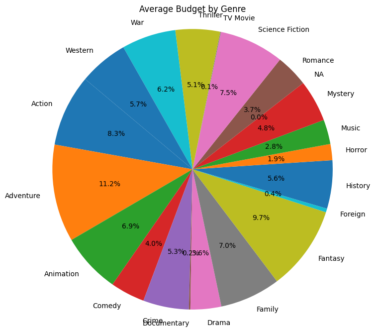

```python
# Plotting average budget as a pie chart
plot_pie_chart(grouped_df_q2, 'avg_budget', 'genre', 'Average Budget by Genre')
```

But what about revenue? Are these (or at least some of these) genres going to appear in the top five list? Let's see...

```python
grouped_df_q2.sort_values(by='avg_revenue', ascending=False).head(5)
```

|  | genre | avg_popularity | avg_budget | avg_revenue |
| --- | --- | --- | --- | --- |
| 1 | Adventure | 1.154259 | 3.754369e+07 | 1.131379e+08 |
| 8 | Fantasy | 0.992840 | 3.261259e+07 | 9.631366e+07 |
| 2 | Animation | 0.852182 | 2.315978e+07 | 7.525606e+07 |
| 0 | Action | 0.926274 | 2.772782e+07 | 7.279473e+07 |
| 7 | Family | 0.786668 | 2.335934e+07 | 7.243318e+07 |

Oh? Four of the genres appeared again but with different order? They seem to be popular that many people watch them therefore give more revenue, don't they? Speaking of popularity, we will check that in the next section but now let's present the statistics visually, shall we?

```python
# Plotting average revenue as a pie chart
plot_pie_chart(grouped_df_q2, 'avg_revenue', 'genre', 'Average Budget by Genre')
```

[output not shown]

[output not shown]

Lastly, Why not check popularity? Top five popular genres:

```python
grouped_df_q2.sort_values(by='avg_popularity', ascending=False).head(5)
```

| genre | avg_popularity | avg_budget | avg_revenue |
| --- | --- | --- | --- |
| Adventure | 1.154259 | 3.754369e+07 | 1.131379e+08 |
| Science Fiction | 1.001548 | 2.497268e+07 | 7.014056e+07 |
| Fantasy | 0.992840 | 3.261259e+07 | 9.631366e+07 |
| Action | 0.926274 | 2.772782e+07 | 7.279473e+07 |
| Animation | 0.852182 | 2.315978e+07 | 7.525606e+07 |

Still not far from the ones before huh? Okay, now comes the chart:

[figure not shown]

```python
# Plotting average popularity as a pie chart
plot_pie_chart(grouped_df_q2, 'avg_popularity', 'genre', 'Average Budget by Genre')
```

## Limitations

While this analysis provided valuable insights, several limitations should be considered:

- **Missing or incomplete data:** Some movies may have missing or zero values for important fields like budget or revenue, which could skew the averages and visualizations.
- **Outliers:** High-budget blockbusters or exceptionally low-budget films can impact mean values. A median or trimmed mean might provide a different perspective.
- **Temporal component ignored:** Since this analysis did not break down trends over time (e.g., yearly), it does not reveal how genre-specific budgets or revenues may have evolved historically.
- **Data bias:** The dataset may primarily feature more well-known or commercially successful films, possibly underrepresenting independent or niche movies.

## Conclusions

Throughout this project, we performed an exploratory data analysis on a movie dataset with a focus on understanding how various features such as genre, popularity, budget, and revenue relate to one another. The primary objective was to derive meaningful insights from the data and present them through effective visualizations and statistical summaries.

We began by cleaning and preparing the dataset to ensure it was ready for analysis. This included addressing missing values, filtering out anomalies, and selecting relevant columns for our investigation. Once the dataset was refined, we grouped the data by genre, which allowed us to compute the average values of key metrics like popularity, budget, and revenue for each genre.

### Further Exploration

While this analysis provided valuable insights, it also opened up new questions worth exploring:

How does the revenue-to-budget ratio vary by genre, and which genres tend to be more profitable? Does popularity correlate strongly with revenue or budget within each genre? How have these trends evolved over time, and do certain genres perform better during specific periods (e.g., summer blockbusters)? Could other factors such as director reputation, cast size, or marketing expenses further explain these patterns?

### Final Thoughts

In conclusion, while this project provides a solid overview of how movie genres relate to budget and revenue, these insights should be interpreted with the understanding that the analysis has certain limitations. Addressing these factors in future work could lead to a more robust and comprehensive understanding of industry patterns.

```python
# Running this cell will execute a bash command to convert this notebook to an .html file
!python -m nbconvert --to html Investigate_a_Dataset.ipynb
```

```
[NbConvertApp] Converting notebook Investigate_a_Dataset.ipynb to html
[NbConvertApp] WARNING | Alternative text is missing on 6 image(s).
[NbConvertApp] Writing 979431 bytes to Investigate_a_Dataset.html
```